# Model estimation

# What are we going to talk about

1. The point of estimation
2. Techniques
3. Practicalities

# Estimation and Identification

## Objective

- Want to build *empirical* models
  - fit the model to data
  - set model parameters given data
- How to estimate?
  - plug in directly
  - up-scaling and down-scaling
  - statistical estimation

## Kinds of parameters

- There are two kinds of parameters:
  1. “what is there” parameters
  2. “how it works” parameters
- Some can be set directly
- Others need some estimation
- Often we don’t know

## Example fishing boats

- Building an ABM of boats going fishing
- Key parameter: number of boats
- If we have data on number of boats: no estimation needed
  - what if boats are heterogeneous?
  - size, captain’s skill, quality of maintenance…
- Ignore heterogeneity $\to$ lack of realism?
- Accept heterogeneity $\to$
  1. more complexity
  2. more parameters
- Abstract away $\to$
  1. ignore boats, focus on “fishing power”

## What is a model?

- A model is:
  - a collection of causal relationships
  - embedded in algorithms
  - modulated by parameters
  - **counterfactual**
- Data is:
  - **factual**

## The problem of induction

- Set **counterfactual** parameters through **factual** observations
  - Learn about what could have happened given what happened
- Let’s do it! Can it be done?
  - Depends on the assumed model
  - Depends on the availability of data
  - Sometimes it cannot be done
  - Most of the time, it can only be done in parts
  - **identification**

## Example: consumer decisions

- If I assume perfect rationality
  - If I have lab-experiment data (conjoint analysis)…
  - If I have real-life decisions (random utility models)…
- If I assume imperfect rationality
  - Regardless of data available, it depends on how irrational
- What matters:
  1. quality of data
  2. assumptions
  3. connections between parameters

## Identification

- **Observational equivalence**
- **Under-identification** (data cannot inform…)
- **Partial identification** (parameters are un-separable)
- **Weak identification** (technical issues, poor information)

## Simple examples

- Two people sitting on a scale
- Check if a coin is loaded with two observation
- Two potential equilibria from same starting condition

## Public health example

Murray, E. J., Robins, J. M., Seage, G. R., Freedberg, K. A., & Hernán, M. A. (2020). The Challenges of Parameterizing Direct Effects in Individual-Level Simulation Models.

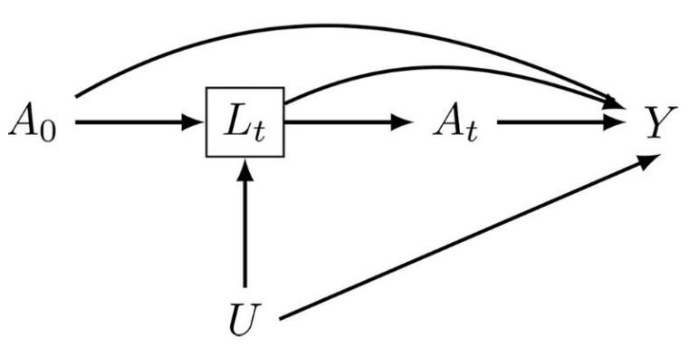

## Macroeconomics example

Canova, Fabio, and Luca Sala. “Back to square one: Identification issues in DSGE models.” Journal of Monetary Economics 56.4 (2009): 431-449.

- Weak identification pervasive in DSGE
- Validation techniques (comparing impulse responses out-of-sample) do not help
- $\to$ wrong with high degree of confidence

## What to do?

- Accept identification issues
  1. Use methods that are honest about unknown parameters
  2. Try to see if anything can be said with some/all unknown parameters
- Add assumptions to make it more identifiable
  - Manski’s *law of decreasing credibility*
  - “Stronger assumptions yield conclusions that are more powerful but less credible”

# Techniques

## In the olden days

- Take an equation-based model
  $$f(\theta)$$
- Make some assumptions about data $x$ such that we can write likelihood function
  $$L(\theta | x)$$
- Maximize function for parameters $\theta$
  - Clear definition of optimum
  - Clear connection between assumptions and likelihood
  - Some identification problems are easy to spot
  - Point predictions
  - Needs sensitivity analysis
  - Maximization may be hard

## Likelihood alternatives

- ABMs do not have likelihoods
- If your model is *very* fast:
  - MC likelihood
  - Pseudo-likelihood

## Example: animal tracking

Hooten, M., Wikle, C., & Schwob, M. (2020). Statistical Implementations of Agent‐Based Demographic Models. International Statistical Review, https://doi.org/10.1111/insr.12399

- Tracking a set of animals
  - Each step, they survive with probability $\theta$
  - Each step, if alive, their tracker reports their presence with probability $p$
- Given a set of track time series
  - What are $\theta$ and $p$

## Example: animal tracking (2)

- MC Likelihood:
  - Pick $\theta,p$
  - Run *many* simulations
  - Likelihood is how many individual time series match entirely
- Pseudo-likelihood:
  - Pick $\theta,p$
  - Run *many* simulations
  - Likelihood is how many observations at each time point for each individual match

## Likelihood alternatives - problems

- Computational expensive
- In large time series exact matches are very unlikely
- Only point estimates:
  - Need to validate
  - Need to do sensitivity analysis
- Usually not all matches are equally important
- Keane, M. P., & Wolpin, K. I. (2007). Exploring the usefulness of a nonrandom holdout sample for model validation: Welfare effects on female behavior. International Economic Review, 48(4), 1351–1378. https://doi.org/10.1111/j.1468-2354.2007.00465.x

## Summary statistics

- Summarise real world data into a set of statistics
- Summarise synthetic data into the same set
- Get them as close as possible
- Two conceptual schools of thought:
  - Indirect inference
  - Approximate Bayesian Computation
- Connection to “Pattern Oriented Modelling”

## Indirect Inference diagram

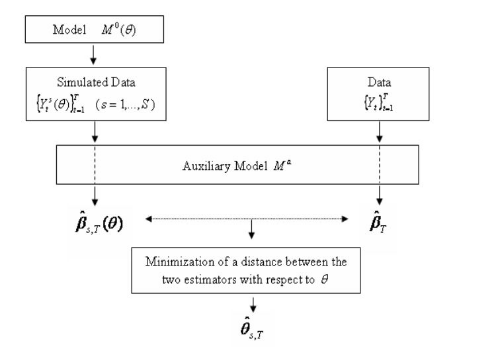

## Indirect Inference

- Fit an *auxiliary* model (usually a regression) to the real data
- Fit the same model to the data coming out of the ABM
- Keep changing ABM parameters ($\theta$) until the *auxiliary* model’s parameters $\beta$ are as close as possible
  $$\min (\beta_{\text{real}} - \beta_{\text{abm}}(\theta))^T W (\beta_{\text{real}} - \beta_{\text{abm}}(\theta))$$

## Indirect Inference (example)

Zhao, Linqiao. A model of limit-order book dynamics and a consistent estimation procedure. Diss. Carnegie Mellon University, 2010.

- Financial simulation
- Set price time series with an AR15 model
- Use the model to generate fake synthetic price time series
- Fit this synthetic time series to the same AR15 model
- Compare the parameters of the two regressions

## Indirect inference magic

- Indirect inference is a **consistent** estimator, if:
  1. The auxiliary model must converge to a specific value
  2. Each $\theta$ will be associated with only one $b(\theta)$ (in the neigbhorhood of the true value)
- Very weak assumptions!
- Assumptions do not depend on the quality of the auxiliary model!
- But
  - impossible to prove
  - Probably not true in many ABMs (see: “Estimation of ergodic agent-based models by simulated minimum distance”)
- Point estimate but Gaussian confidence intervals with some further assumptions

## Approximate bayesian computation

- Like indirect inference but:
  - Add prejudice priors
  - $\to$ nice confidence intervals
- Practical tradeoff:
  - Often gives up on consistency (choice of summary statistics)
  - But much easier to diagnose identification issues

## Simple Rejection ABC:

- Compute some summary statistics in the real world
- Run the model many times drawing parameters at random from their priors
- “Accept” all parameters that generate summary statistics close enough to the real world’s ones

## Simple Rejection ABC, example:

van der Vaart, E., Beaumont, M. A., Johnston, A. S. A., & Sibly, R. M. (2015). Calibration and evaluation of individual-based models using Approximate Bayesian Computation. Ecological Modelling, 312, 182–190. https://doi.org/10.1016/j.ecolmodel.2015.05.020

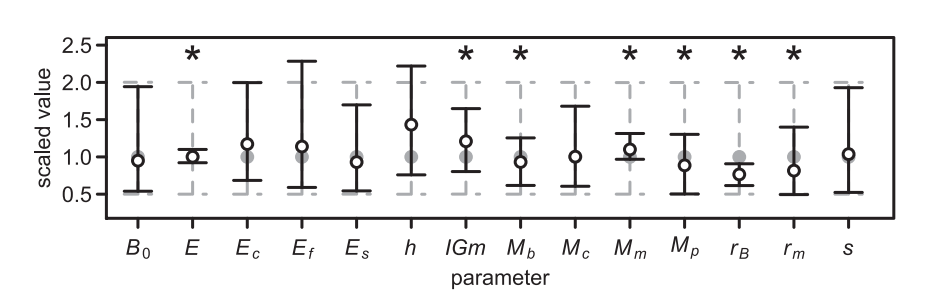

## ABC variants

- “Reference Table” ABC
- Regression-adjusted ABC
- MCMC ABC
- SMC/Particle Filter ABC

# Practicalities

## Keep model simple

- Estimation requires a lot of runs
- Premium on speed
- KISS

## Choice of maximizers/methods

- Lots of methods require some form of optimization:
  - Genetic algorithms
  - BACCO/Meta-models
  - Nelder-mead
  - …
- No free lunch

## Choice of methods

- Many methods
- Unfortunately a priori it is hard to tell which is better
- No free lunch
- http://carrknight.github.io/assets/nofreelunch.html

## Choice of summary statistics

$$\min (\beta_{\text{real}} - \beta_{\text{abm}}(\theta))^T W (\beta_{\text{real}} - \beta_{\text{abm}}(\theta))$$

- Many summary statistics are possible
- How to weigh them?
- Regression/regularization can help:
  - Carrella, E., Bailey, R., & Madsen, J. (2020). Calibrating Agent-Based Models with Linear Regressions. Journal of Artificial Societies and Social Simulation, 23(1). https://doi.org/10.18564/jasss.4150

## Priorities

1. Figure out what parameters been identified
   - confidence intervals
   - cross-validation
2. Carry over that uncertainty when doing policy analysis
   - Sensitivity analysis bounds
3. Validate

## Terminology

- Calibration vs Estimation ?

## When to calibrate?

- Wait till the end?
  - *“pride goes before a fall”*
  - “O purpo s’adda cocere cu’ l’acqua soja”
- Within a development loop
  - Develop a bit, calibrate and validate
  - Fix next validation error
  - Overfitting/p-hacking